# Built environment and mortality risk from cardiovascular disease and diabetes in Medellin, Colombia: an ecological study

Econometric analysis of the corrected manuscript submitted to Landscape and Urban Planning journal

Jorge E. Patiño, Andy Hong, Juan C. Duque, Kazem Rahimi, Silvana Zapata, and Verónica Lopera

01 April, 2021

Quantitative analysis of the relationships between built-environment features and public health outcomes in Medellin, Colombia, at the neighborhood (barrio) level. International collaboration between the Oxford Martin School at Oxford University (UK), RiSE Group at EAFIT University (CO), and the Medellin’s Health Office (CO).

**Acknowledgements:**  
This work was completed with support from the PEAK Urban Programme, supported by 501 UKRI’s Global Challenge Research Fund, Grant Ref.: ES/P011055/1. Additionally, Kazem Rahimi is in receipt of grants from the National Institute for Health Research (NIHR) Oxford Biomedical Research Centre (BRC), the Oxford Martin School (OMS), University of Oxford and the British Heart Foundation grant ref: PG/18/65/33872. The views expressed are those of the authors and not necessarily those of the OMS, the UK National Health Service (NHS), the NIHR or the Department of Health and Social Care. The funding organizations had no role in design or conduct of the study; collection, management, analysis, and interpretation of the data; preparation, review, or approval of the manuscript; or decision to submit the manuscript for publication.

# Datasets

**Spatial units of analysis:** inputs/data_MDE_health_built_env_geo.shp  
**Variables:** data_MDE_health_built_env.csv

# Computing environment

Load libraries:

```r
library(sp) # for creating neighborhoods contiguity matrix
library(sf) # for handling spatial units of analysis
library(tidyverse) # for plots and maps
library(MASS) # for robust regression
library(mctest) # for multicolinearity tests
library(stargazer) # for models and dataset summaries
library(jtools) # for single effects plots, used for quadratic variables
library(gridExtra) # for arranging several plots in single graph
library(spdep) # for spatial dependence tests
library(fields) # for calculating distances for distance contiguity matrix
library(tmap) # for mapping
library(corrplot) # for correlation matrix
```

Load datasets and join:

```r
df = read_csv("../inputs/data_MDE_health_built_env.cvs")
sf = st_read("../inputs/data_MDE_health_built_env_geo.shp")
dataset = left_join(sf, df, by = "CODIGO")
rm(df, sf)
```

Remove variable X1;

```r
dataset$X1 = NULL
```

# Mapping

## Mortality rates

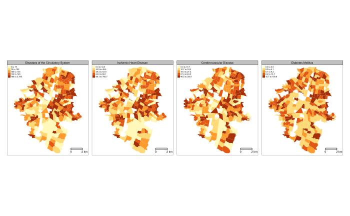

```r
tm_shape(dataset) +
  tm_fill(col = c("DCS_avg", "IHD_avg", "CVD_avg", "DM_avg"),
          title = c("", "", "", ""),
          style = "quantile",
          ) +
  tm_facets(ncol = 4) +
  tm_scale_bar(breaks = c(0, 2), position = c("RIGHT", "BOTTOM")) +
  tm_layout(asp = 0.9,
            legend.position = c("LEFT", "TOP"),
            legend.text.size = 0.35,
            legend.width = 0.35,
            panel.show = TRUE,
            panel.labels = c("Diseases of the Circulatory System",
                             "Ischemic Heart Disesae",
                             "Cerebrovascular Disease",
                             "Diabetes Mellitus"),
            panel.label.size = 0.5,
            frame = "gray50",
            )
tmap_save(filename = "../outputs/fig 1 mortality rates maps.png",
          height = 5,
          width = 16,
          units = "cm",
          dpi = 300)
```

## Urban form metrics

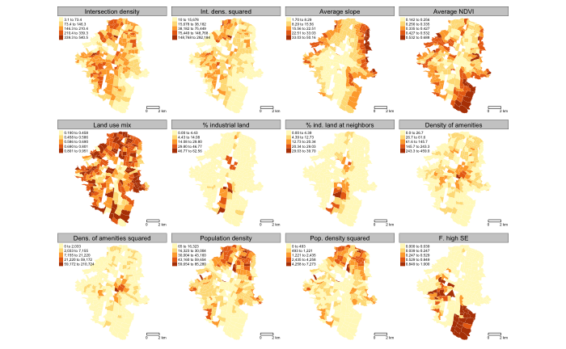

```r
tm_shape(dataset) +
  tm_fill(col = c("int_dens",
                  "int_dens_2",
                  "slope_mean",
                  "NDVI_mean",
                  "lu_entropy_a",
                  "p_area_ind",
                  "sl_p_ind",
                  "POI_dens",
                  "POI_dens_2",
                  "pdens_2017",
                  "pdens_2_t",
                  "f_hig_SES"),
          title = c("", "", "", "", "", "", "", "", "", "", "", ""),
          style = "jenks",
          n = 5
          ) +
  tm_scale_bar(breaks = c(0, 2), position = c("RIGHT", "BOTTOM")) +
  tm_layout(asp = 1.1,
            legend.position = c("LEFT", "TOP"),
            legend.text.size = 0.5,
            legend.width = 0.4,
            panel.show = TRUE,
            panel.labels = c("Intersection density",
                             "Int. dens. squared",
                             "Average slope",
                             "Average NDVI",
                             "Land use mix",
                             "% industrial land",
                             "% ind. land at neighbors",
                             "Density of amenities",
                             "Dens. of amenities squared",
                             "Population density",
                             "Pop. density squared",
                             "F. high SE"),
            panel.label.size = 0.85,
            frame = FALSE,
            )
```

# Econometrics

## Dataset summary:

```r
stargazer(st_drop_geometry(dataset), type = "text", digits = 2)
```

```
=========================================================================
Statistic     N    Mean    St. Dev.   Min  Pctl(25)  Pctl(75)     Max
-------------------------------------------------------------------------
DCS_avg      245  165.65    278.13   0.00    82.05    176.14    3,785.00
IHD_avg      245   71.71     82.63   0.00    36.82     77.84     766.69
CVD_avg      245   29.94     37.24   0.00    13.12     36.82     365.09
DM_avg       245   10.72     15.32   0.00    2.30      13.78     158.75
int_dens     245  139.00     79.44   3.09    86.18    189.10     540.54
int_dens_2   245 25,605.58 29,960.60 9.55  7,426.39  35,759.24 292,184.10
slope_mean   245   14.28     9.56    1.70    6.27      19.57     50.16
NDVI_mean    245   0.35      0.11    0.14    0.26      0.43       0.69
lu_entropy_a 245   0.69      0.14    0.19    0.61      0.80       0.95
p_area_ind   245   2.76      10.12     0       0         0         63
sl_p_ind     245   2.53      6.00      0       0        1.4        40
POI_dens     245   33.68     39.92   0.00    12.63     41.88     459.05
POI_dens_2   245 2,721.45  14,279.90 0.00   159.42   1,754.10  210,724.10
pdens_2017   245 27,122.25 16,570.69 65.09 15,202.34 37,548.68 85,279.71
pdens_2_t    245 1,009.08  1,166.37  0.004  231.11   1,409.90   7,272.63
f_hig_SES    245   0.16      0.33      0       0       0.01        1
-------------------------------------------------------------------------
```

## Correlation matrix:

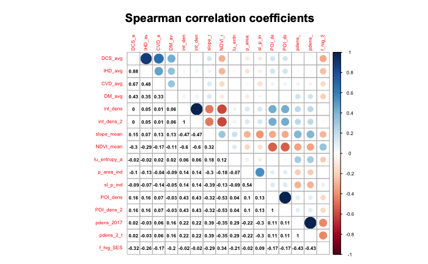

## Linear models

Notes: Land use entropy adjusted with firm location data from DANE (see paper for a detailed explanation).

```r
DCS_ols = lm( #OLS
  DCS_avg ~
    int_dens +
    I(int_dens^2) +
    slope_mean +
    NDVI_mean +
    lu_entropy_a +
    p_area_ind +
    sl_p_ind +
    POI_dens +
    I(POI_dens^2) +
    pdens_2017 +
    I(pdens_2017^2) +
    f_hig_SES,
  data = dataset)
DCS_rl = rlm( # robust regression
  DCS_avg ~
    int_dens +
    I(int_dens^2) +
    slope_mean +
    NDVI_mean +
    lu_entropy_a +
    p_area_ind +
    sl_p_ind +
    POI_dens +
    I(POI_dens^2) +
    pdens_2017 +
    I(pdens_2017^2) +
    f_hig_SES,
  data = dataset)
IHD_ols = lm(
  IHD_avg ~
    int_dens +
    I(int_dens^2) +
    slope_mean +
    NDVI_mean +
    lu_entropy_a +
    p_area_ind +
    sl_p_ind +
    POI_dens +
    I(POI_dens^2) +
    pdens_2017 +
    I(pdens_2017^2) +
    f_hig_SES,
  data = dataset)
IHD_rl = rlm(
  IHD_avg ~
    int_dens +
    I(int_dens^2) +
    slope_mean +
    NDVI_mean +
    lu_entropy_a +
    p_area_ind +
    sl_p_ind +
    POI_dens +
    I(POI_dens^2) +
    pdens_2017 +
    I(pdens_2017^2) +
    f_hig_SES,
  data = dataset)
CVD_ols = lm(
  CVD_avg ~
    int_dens +
    I(int_dens^2) +
    slope_mean +
    NDVI_mean +
    lu_entropy_a +
    p_area_ind +
    sl_p_ind +
    POI_dens +
    I(POI_dens^2) +
    pdens_2017 +
    I(pdens_2017^2) +
    f_hig_SES,
  data = dataset)
CVD_rl = rlm(
  CVD_avg ~
    int_dens +
    I(int_dens^2) +
    slope_mean +
    NDVI_mean +
    lu_entropy_a +
    p_area_ind +
    sl_p_ind +
    POI_dens +
    I(POI_dens^2) +
    pdens_2017 +
    I(pdens_2017^2) +
    f_hig_SES,
  data = dataset)
DM_ols = lm(
  DM_avg ~
    int_dens +
    I(int_dens^2) +
    slope_mean +
    NDVI_mean +
    lu_entropy_a +
    p_area_ind +
    sl_p_ind +
    POI_dens +
    I(POI_dens^2) +
    pdens_2017 +
    I(pdens_2017^2) +
    f_hig_SES,
  data = dataset)
DM_rl = rlm(
  DM_avg ~
    int_dens +
    I(int_dens^2) +
    slope_mean +
    NDVI_mean +
    lu_entropy_a +
    p_area_ind +
    sl_p_ind +
    POI_dens +
    I(POI_dens^2) +
    pdens_2017 +
    I(pdens_2017^2) +
    f_hig_SES,
  data = dataset)
```

## Multicolinearity Condition Number

Calculated on OLS models

```r
paste0("DCS: ", omcdiag(DCS_ols, Inter = F)$odiags[6])
```

```
[1] "DCS: 23.3965069364894"
```

```r
paste0("IHD: ", omcdiag(IHD_ols, Inter = F)$odiags[6])
```

```
[1] "IHD: 23.3965069364894"
```

```r
paste0("CVD: ", omcdiag(CVD_ols, Inter = F)$odiags[6])
```

```
[1] "CVD: 23.3965069364894"
```

```r
paste0("DM: ", omcdiag(DM_ols, Inter = F)$odiags[6])
```

```
[1] "DM: 23.3965069364894"
```

## Spatial dependence tests

### Create contiguity matrices

```r
# build contiguity matrix
Wr = poly2nb(as_Spatial(dataset), queen = FALSE) # Rook matrix
Wq = poly2nb(as_Spatial(dataset), queen = TRUE) # Queen matrix
# convert matrix to lists
listWr = nb2listw(Wr, style = "W", zero.policy = TRUE)
listWq = nb2listw(Wq, style = "W", zero.policy = TRUE)
# inverse distance matrix
mycoords <- coordinates(as_Spatial(dataset))
mydm <- rdist(mycoords)                  # computes distance in projected coordinates
for(i in 1:dim(mydm)[1]) {mydm[i,i] = 0} # renders exactly zero all diagonal elements
mydm[mydm > 1000] <- 0                   # all distances > 1000 miles are set to zero
mydm <- ifelse(mydm!=0, 1/mydm, mydm)    # inverting distances
listWid <- mat2listw(mydm, style="W")    # create a (normalized) listw object
```

### Lagrange Multiplier (LM) tests

Test run on OLS models using three different contiguity matrix specifications:  
- Rook: `listWr`.  
- Queen: `listWq`.  
- Inverse distance: `listWid`.

#### DCS

```r
LM_Wr = lm.LMtests(DCS_ols, listWr, test=c("LMerr", "LMlag", "RLMerr", "RLMlag"))
LM_Wq = lm.LMtests(DCS_ols, listWq, test=c("LMerr", "LMlag", "RLMerr", "RLMlag"))
LM_Wid = lm.LMtests(DCS_ols, listWid, test=c("LMerr", "LMlag", "RLMerr", "RLMlag"))
summary(LM_Wr)
```

```
    Lagrange multiplier diagnostics for spatial dependence
data:
model: lm(formula = DCS_avg ~ int_dens + I(int_dens^2) + slope_mean + NDVI_mean + lu_entropy_a +
p_area_ind + sl_p_ind + POI_dens + I(POI_dens^2) + pdens_2017 + pdens_2_t + f_hig_SES, data =
dataset)
weights: listWr

       statistic parameter p.value
LMerr    2.11490         1  0.1459
LMlag    1.42866         1  0.2320
RLMerr   0.84109         1  0.3591
RLMlag   0.15485         1  0.6939
```

```r
summary(LM_Wq)
```

```
    Lagrange multiplier diagnostics for spatial dependence
data:
model: lm(formula = DCS_avg ~ int_dens + I(int_dens^2) + slope_mean + NDVI_mean + lu_entropy_a +
p_area_ind + sl_p_ind + POI_dens + I(POI_dens^2) + pdens_2017 + pdens_2_t + f_hig_SES, data =
dataset)
weights: listWq

       statistic parameter p.value
LMerr   1.811766         1  0.1783
LMlag   1.322751         1  0.2501
RLMerr  0.543782         1  0.4609
RLMlag  0.054767         1  0.8150
```

```r
summary(LM_Wid)
```

```
    Lagrange multiplier diagnostics for spatial dependence
data:
model: lm(formula = DCS_avg ~ int_dens + I(int_dens^2) + slope_mean + NDVI_mean + lu_entropy_a +
p_area_ind + sl_p_ind + POI_dens + I(POI_dens^2) + pdens_2017 + pdens_2_t + f_hig_SES, data =
dataset)
weights: listWid

       statistic parameter p.value
LMerr  0.6939043         1 0.40484
LMlag  0.0026431         1 0.95900
RLMerr 4.0011842         1 0.04547 *
RLMlag 3.3099230         1 0.06886 .
---
Signif. codes:  0 ‘***’ 0.001 ‘**’ 0.01 ‘*’ 0.05 ‘.’ 0.1 ‘ ’ 1
```

```r
rm(LM_Wr, LM_Wq, LM_Wid)
```

#### IHD

```r
LM_Wr = lm.LMtests(IHD_ols, listWr, test=c("LMerr", "LMlag", "RLMerr", "RLMlag"))
LM_Wq = lm.LMtests(IHD_ols, listWq, test=c("LMerr", "LMlag", "RLMerr", "RLMlag"))
LM_Wid = lm.LMtests(IHD_ols, listWid, test=c("LMerr", "LMlag", "RLMerr", "RLMlag"))
summary(LM_Wr)
```

```
    Lagrange multiplier diagnostics for spatial dependence
data:
model: lm(formula = IHD_avg ~ int_dens + I(int_dens^2) + slope_mean + NDVI_mean + lu_entropy_a + p_area_ind + sl_p_ind +
POI_dens + I(POI_dens^2) + pdens_2017 + pdens_2_t + f_hig_SES, data = dataset)
weights: listWr

       statistic parameter p.value
LMerr  0.0025345         1 0.95985
LMlag  1.2549411         1 0.26261
RLMerr 4.3055719         1 0.03799 *
RLMlag 5.5579785         1 0.01840 *
---
Signif. codes:  0 ‘***’ 0.001 ‘**’ 0.01 ‘*’ 0.05 ‘.’ 0.1 ‘ ’ 1
```

```r
summary(LM_Wq)
```

```
    Lagrange multiplier diagnostics for spatial dependence
data:
model: lm(formula = IHD_avg ~ int_dens + I(int_dens^2) + slope_mean + NDVI_mean + lu_entropy_a + p_area_ind + sl_p_ind +
POI_dens + I(POI_dens^2) + pdens_2017 + pdens_2_t + f_hig_SES, data = dataset)
weights: listWq

       statistic parameter p.value
LMerr  0.0015992         1  0.9681
LMlag  1.1569514         1  0.2821
RLMerr 3.4538878         1  0.0631 .
RLMlag 4.6092400         1  0.0318 *
---
Signif. codes:  0 ‘***’ 0.001 ‘**’ 0.01 ‘*’ 0.05 ‘.’ 0.1 ‘ ’ 1
```

```r
summary(LM_Wid)
```

```
    Lagrange multiplier diagnostics for spatial dependence
data:
model: lm(formula = IHD_avg ~ int_dens + I(int_dens^2) + slope_mean + NDVI_mean + lu_entropy_a + p_area_ind + sl_p_ind +
POI_dens + I(POI_dens^2) + pdens_2017 + pdens_2_t + f_hig_SES, data = dataset)
weights: listWid

       statistic parameter p.value
LMerr    0.24433         1 0.62110
LMlag    2.48326         1 0.11506
RLMerr   3.32377         1 0.06829 .
RLMlag   5.56270         1 0.01835 *
---
Signif. codes:  0 ‘***’ 0.001 ‘**’ 0.01 ‘*’ 0.05 ‘.’ 0.1 ‘ ’ 1
```

```r
rm(LM_Wr, LM_Wq, LM_Wid)
```

#### CeVD

```r
LM_Wr = lm.LMtests(CVD_ols, listWr, test=c("LMerr", "LMlag", "RLMerr", "RLMlag"))
LM_Wq = lm.LMtests(CVD_ols, listWq, test=c("LMerr", "LMlag", "RLMerr", "RLMlag"))
LM_Wid = lm.LMtests(CVD_ols, listWid, test=c("LMerr", "LMlag", "RLMerr", "RLMlag"))
summary(LM_Wr)
```

```
    Lagrange multiplier diagnostics for spatial dependence
data:
model: lm(formula = CVD_avg ~ int_dens + I(int_dens^2) + slope_mean + NDVI_mean + lu_entropy_a + p_area_ind + sl_p_ind +
POI_dens + I(POI_dens^2) + pdens_2017 + pdens_2_t + f_hig_SES, data = dataset)
weights: listWr

       statistic parameter p.value
LMerr    0.31048         1 0.57738
LMlag    1.35691         1 0.24407
RLMerr   3.75547         1 0.05263 .
RLMlag   4.80190         1 0.02843 *
---
Signif. codes:  0 ‘***’ 0.001 ‘**’ 0.01 ‘*’ 0.05 ‘.’ 0.1 ‘ ’ 1
```

```r
summary(LM_Wq)
```

```
    Lagrange multiplier diagnostics for spatial dependence
data:
model: lm(formula = CVD_avg ~ int_dens + I(int_dens^2) + slope_mean + NDVI_mean + lu_entropy_a + p_area_ind + sl_p_ind +
POI_dens + I(POI_dens^2) + pdens_2017 + pdens_2_t + f_hig_SES, data = dataset)
weights: listWq

       statistic parameter p.value
LMerr   0.069842         1 0.79157
LMlag   0.919968         1 0.33748
RLMerr  4.830068         1 0.02797 *
RLMlag  5.680194         1 0.01716 *
---
Signif. codes:  0 ‘***’ 0.001 ‘**’ 0.01 ‘*’ 0.05 ‘.’ 0.1 ‘ ’ 1
```

```r
summary(LM_Wid)
```

```
    Lagrange multiplier diagnostics for spatial dependence
data:
model: lm(formula = CVD_avg ~ int_dens + I(int_dens^2) + slope_mean + NDVI_mean + lu_entropy_a + p_area_ind + sl_p_ind +
POI_dens + I(POI_dens^2) + pdens_2017 + pdens_2_t + f_hig_SES, data = dataset)
weights: listWid

       statistic parameter p.value
LMerr    0.89699         1  0.3436
LMlag    1.73977         1  0.1872
RLMerr   1.19114         1  0.2751
RLMlag   2.03392         1  0.1538
```

```r
rm(LM_Wr, LM_Wq, LM_Wid)
```

#### DM

```r
LM_Wr = lm.LMtests(DM_ols, listWr, test=c("LMerr", "LMlag", "RLMerr", "RLMlag"))
LM_Wq = lm.LMtests(DM_ols, listWq, test=c("LMerr", "LMlag", "RLMerr", "RLMlag"))
LM_Wid = lm.LMtests(DM_ols, listWid, test=c("LMerr", "LMlag", "RLMerr", "RLMlag"))
summary(LM_Wr)
```

```
    Lagrange multiplier diagnostics for spatial dependence
data:
model: lm(formula = DM_avg ~ int_dens + I(int_dens^2) + slope_mean + NDVI_mean + lu_entropy_a + p_area_ind + sl_p_ind +
POI_dens + I(POI_dens^2) + pdens_2017 + pdens_2_t + f_hig_SES, data = dataset)
weights: listWr

       statistic parameter p.value
LMerr    0.54793         1  0.4592
LMlag    1.10558         1  0.2930
RLMerr   1.58222         1  0.2084
RLMlag   2.13987         1  0.1435
```

```r
summary(LM_Wq)
```

```
    Lagrange multiplier diagnostics for spatial dependence
data:
model: lm(formula = DM_avg ~ int_dens + I(int_dens^2) + slope_mean + NDVI_mean + lu_entropy_a + p_area_ind + sl_p_ind +
POI_dens + I(POI_dens^2) + pdens_2017 + pdens_2_t + f_hig_SES, data = dataset)
weights: listWq

       statistic parameter p.value
LMerr    0.34495         1  0.5570
LMlag    0.80091         1  0.3708
RLMerr   1.56679         1  0.2107
RLMlag   2.02275         1  0.1550
```

```r
summary(LM_Wid)
```

```
    Lagrange multiplier diagnostics for spatial dependence
data:
model: lm(formula = DM_avg ~ int_dens + I(int_dens^2) + slope_mean + NDVI_mean + lu_entropy_a + p_area_ind + sl_p_ind +
POI_dens + I(POI_dens^2) + pdens_2017 + pdens_2_t + f_hig_SES, data = dataset)
weights: listWid

       statistic parameter p.value
LMerr    1.14934         1  0.2837
LMlag    1.66319         1  0.1972
RLMerr   0.66295         1  0.4155
RLMlag   1.17680         1  0.2780
```

```r
rm(LM_Wr, LM_Wq, LM_Wid)
```

## Model’s diagnostic plots

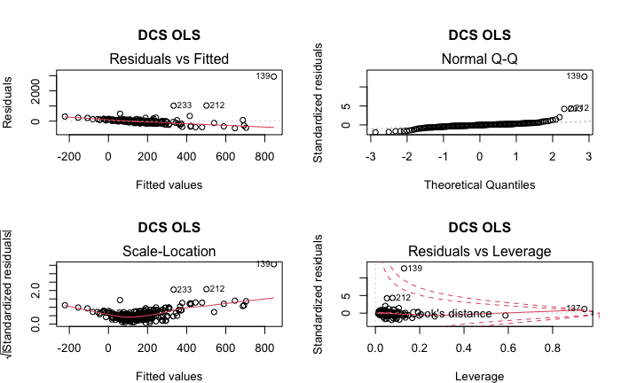

```r
par(mfrow = c(2,2), mar = c(4,4,5,2))
plot(DCS_ols, main = "DCS OLS")
```

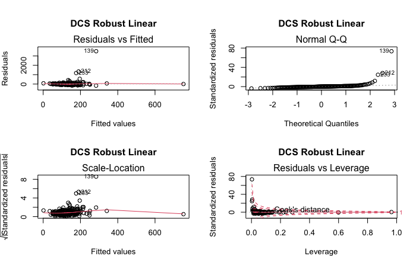

```r
plot(DCS_rl, main = "DCS Robust Linear")
```

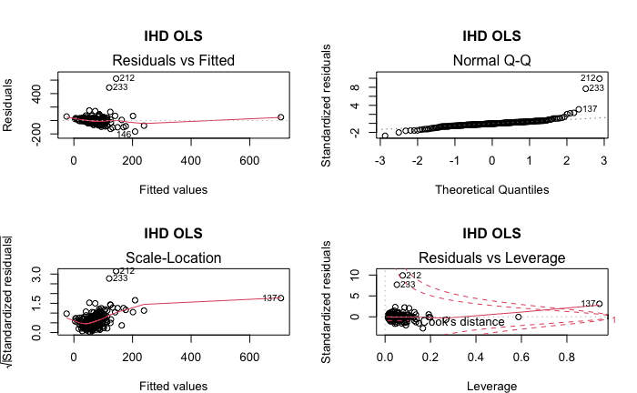

```r
plot(IHD_ols, main = "IHD OLS")
```

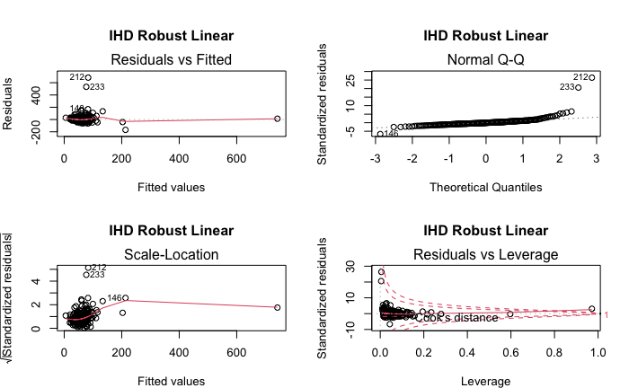

```r
plot(IHD_rl, main = "IHD Robust Linear")
```

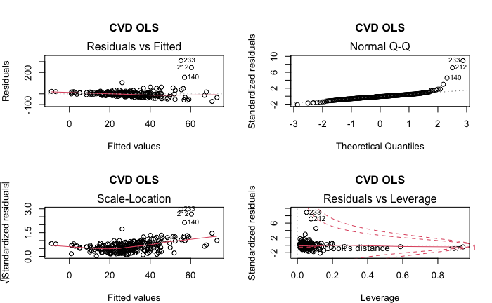

```r
plot(CVD_ols, main = "CVD OLS")
```

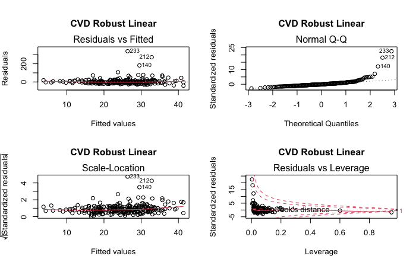

```r
plot(CVD_rl, main = "CVD Robust Linear")
```

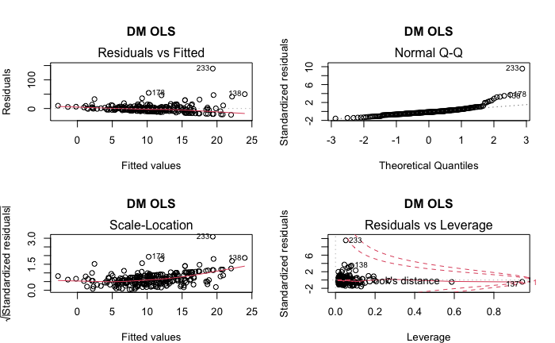

```r
plot(DM_ols, main = "DM OLS")
```

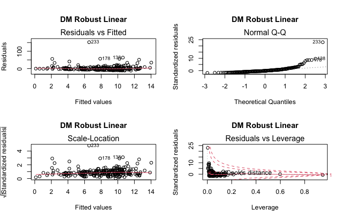

```r
plot(DM_rl, main = "DM Robust Linear")
```

## Models’ residuals plots

### DCS

#### OLS residuals and map:

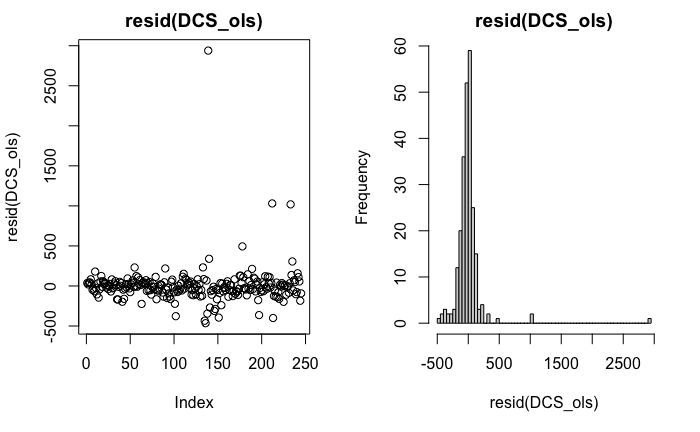

```r
par(mfrow = c(1,2))
plot(resid(DCS_ols), main = "resid(DCS_ols)")
hist(resid(DCS_ols), breaks = 50, main = "resid(DCS_ols)")
```

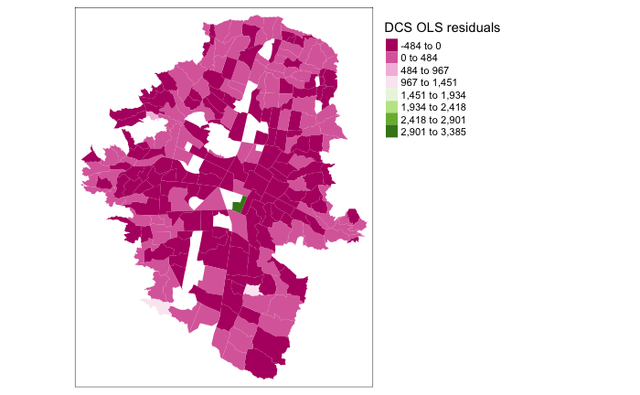

```r
# add residuals to data frame
dataset$res_DCS_ols = resid(DCS_ols)
# map
tm_shape(dataset) +
  tm_fill(col = "res_DCS_ols", title = "DCS OLS residuals",
          style = "sd", n = 7, palette = "PiYG", midpoint = NA) +
  tm_legend(legend.outside = TRUE, legend.outside.position = "right")
```

#### Robust linear regression residuals and map:

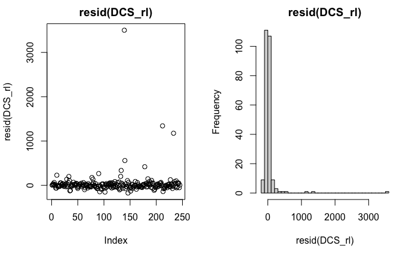

```r
par(mfrow = c(1,2))
plot(resid(DCS_rl), main = "resid(DCS_rl)")
hist(resid(DCS_rl), breaks = 50, main = "resid(DCS_rl)")
```

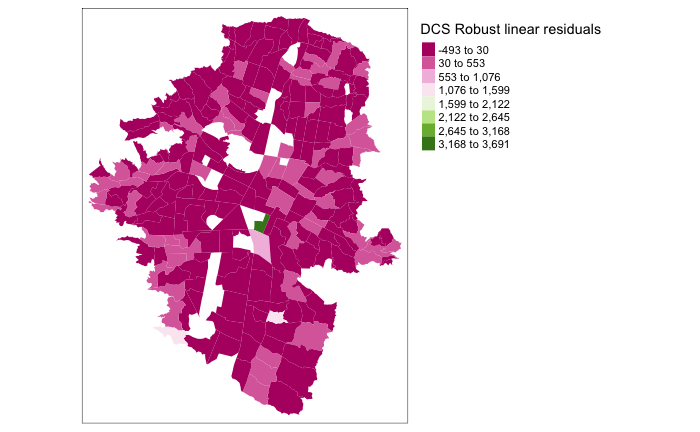

```r
# add residuals to data frame
dataset$res_DCS_rl = resid(DCS_rl)
# map
tm_shape(dataset) +
  tm_fill(col = "res_DCS_rl", title = "DCS Robust linear residuals",
          style = "sd", n = 7, palette = "PiYG", midpoint = NA) +
  tm_legend(legend.outside = TRUE, legend.outside.position = "right")
```

### IHD

#### OLS residuals and map:

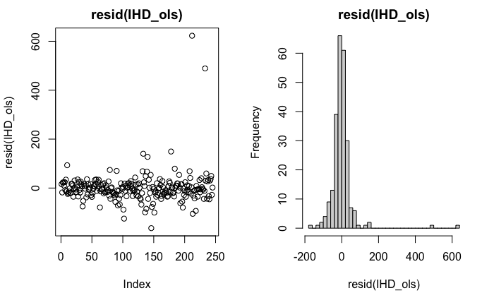

```r
par(mfrow = c(1,2))
plot(resid(IHD_ols), main = "resid(IHD_ols)")
hist(resid(IHD_ols), breaks = 50, main = "resid(IHD_ols)")
```

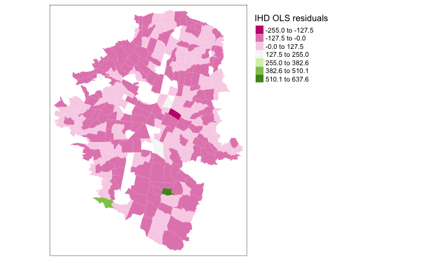

```r
# add residuals to data frame
dataset$res_IHD_ols = resid(IHD_ols)
# map
tm_shape(dataset) +
  tm_fill(col = "res_IHD_ols", title = "IHD OLS residuals",
          style = "sd", n = 7, palette = "PiYG", midpoint = NA) +
  tm_legend(legend.outside = TRUE, legend.outside.position = "right")
```

#### Robust linear regression residuals and map:

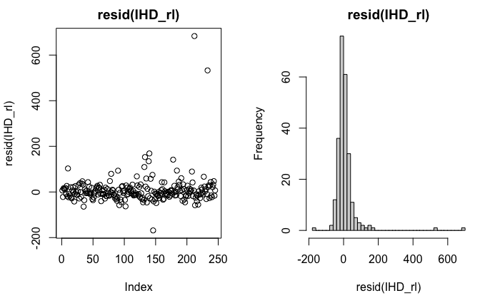

```r
par(mfrow = c(1,2))
plot(resid(IHD_rl), main = "resid(IHD_rl)")
hist(resid(IHD_rl), breaks = 50, main = "resid(IHD_rl)")
```

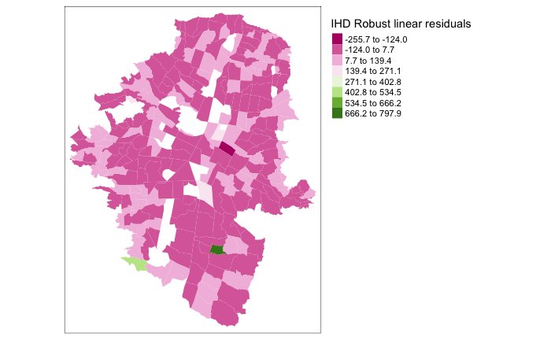

```r
# add residuals to data frame
dataset$res_IHD_rl = resid(IHD_rl)
# map
tm_shape(dataset) +
  tm_fill(col = "res_IHD_rl", title = "IHD Robust linear residuals",
          style = "sd", n = 7, palette = "PiYG", midpoint = NA) +
  tm_legend(legend.outside = TRUE, legend.outside.position = "right")
```

### CVD

#### OLS residuals and map:

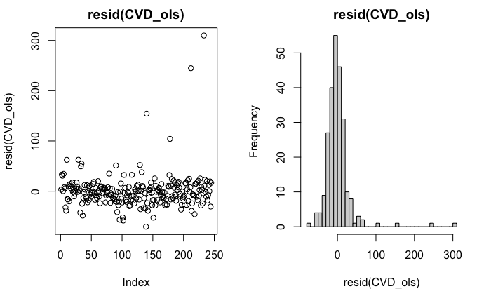

```r
par(mfrow = c(1,2))
plot(resid(CVD_ols), main = "resid(CVD_ols)")
hist(resid(CVD_ols), breaks = 50, main = "resid(CVD_ols)")
```

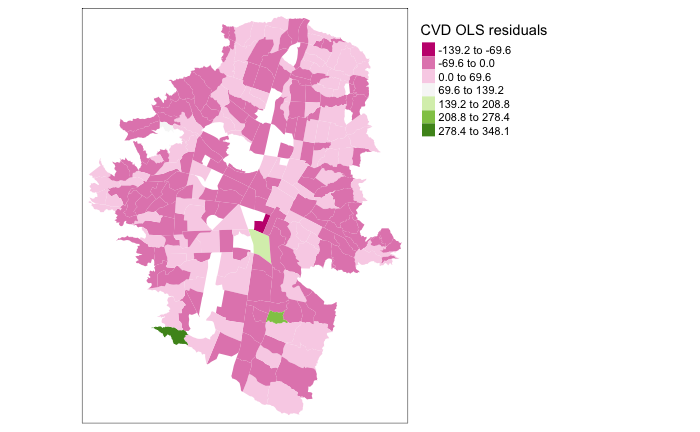

```r
# add residuals to data frame
dataset$res_CVD_ols = resid(CVD_ols)
# map
tm_shape(dataset) +
  tm_fill(col = "res_CVD_ols", title = "CVD OLS residuals",
          style = "sd", n = 7, palette = "PiYG", midpoint = NA) +
  tm_legend(legend.outside = TRUE, legend.outside.position = "right")
```

#### Robust linear regression residuals and map:

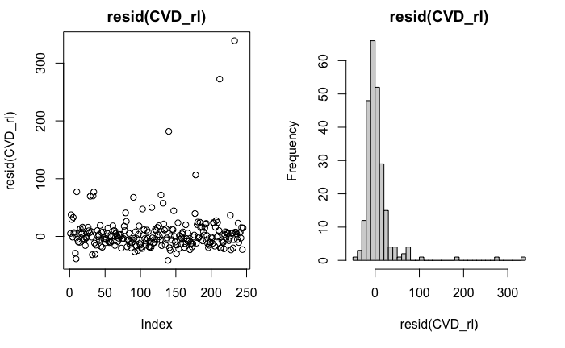

```r
par(mfrow = c(1,2))
plot(resid(CVD_rl), main = "resid(CVD_rl)")
hist(resid(CVD_rl), breaks = 50, main = "resid(CVD_rl)")
```

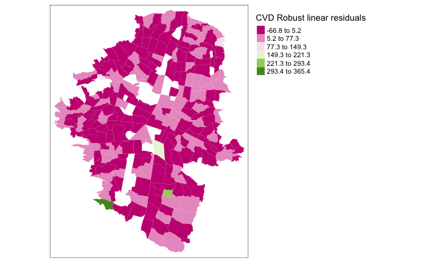

```r
# add residuals to data frame
dataset$res_CVD_rl = resid(CVD_rl)
# map
tm_shape(dataset) +
  tm_fill(col = "res_CVD_rl", title = "CVD Robust linear residuals",
          style = "sd", n = 7, palette = "PiYG", midpoint = NA) +
  tm_legend(legend.outside = TRUE, legend.outside.position = "right")
```

### DM

#### OLS residuals and map:

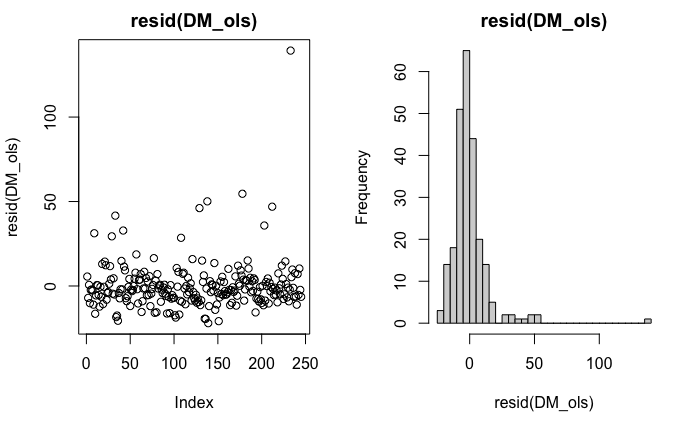

```r
par(mfrow = c(1,2))
plot(resid(DM_ols), main = "resid(DM_ols)")
hist(resid(DM_ols), breaks = 50, main = "resid(DM_ols)")
```

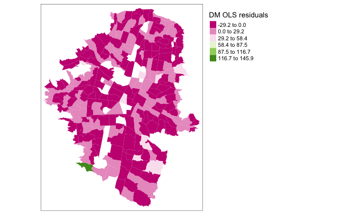

```r
# add residuals to data frame
dataset$res_DM_ols = resid(DM_ols)
# map
tm_shape(dataset) +
  tm_fill(col = "res_DM_ols", title = "DM OLS residuals",
          style = "sd", n = 7, palette = "PiYG", midpoint = NA) +
  tm_legend(legend.outside = TRUE, legend.outside.position = "right")
```

#### Robust linear regression residuals and map:

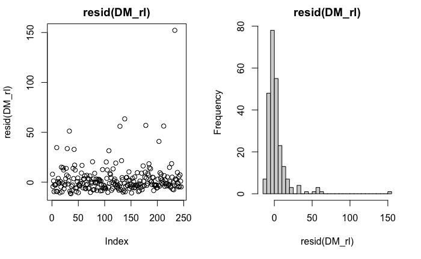

```r
par(mfrow = c(1,2))
plot(resid(DM_rl), main = "resid(DM_rl)")
hist(resid(DM_rl), breaks = 50, main = "resid(DM_rl)")
```

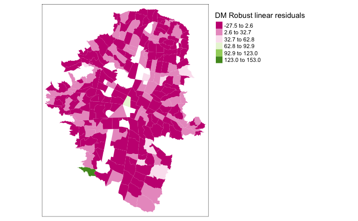

```r
# add residuals to data frame
dataset$res_DM_rl = resid(DM_rl)
# map
tm_shape(dataset) +
  tm_fill(col = "res_DM_rl", title = "DM Robust linear residuals",
          style = "sd", n = 7, palette = "PiYG", midpoint = NA) +
  tm_legend(legend.outside = TRUE, legend.outside.position = "right")
```

## Effects plots

### Plots with local references

Values from 3 Medellin administrative neighborhoods. #### Selected neighborhoods:  
- El Tesoro: int_dens 52, POI_dens 5.1, pdens_2017 8966  
- Sevilla: int_dens 207, POI_dens 118, pdens_2017 11046  
- Francisco Antonio Zea: int_dens 438, POI_dens 34, pdens_2017 61024

#### Intersection density

Models with significant term: DCS, CVD, and DM

```r
p1 = effect_plot(DCS_rl, pred = int_dens, interval = TRUE, robust = TRUE) +
  xlim(0, 500) +
  #ylim(0, 150) +
  xlab("") +
  ylab("Diseases of the Circulatory System") +
  geom_vline(xintercept = 52, colour = "orange", alpha = 0.5) +
  geom_vline(xintercept = 207, colour = "orange", alpha = 0.5) +
  geom_vline(xintercept = 438, colour = "orange", alpha = 0.5)
p2 = effect_plot(CVD_rl, pred = int_dens, interval = TRUE, robust = TRUE) +
  xlim(0, 500) +
  #ylim(0, 30) +
  xlab("") +
  ylab("Cerebrovascular Disease") +
  geom_vline(xintercept = 52, colour = "orange", alpha = 0.5) +
  geom_vline(xintercept = 207, colour = "orange", alpha = 0.5) +
  geom_vline(xintercept = 438, colour = "orange", alpha = 0.5)
p3 = effect_plot(DM_rl, pred = int_dens, interval = TRUE, robust = TRUE) +
  xlim(0, 500) +
  #ylim(0, 15) +
  xlab("Intersection density") +
  ylab("Diabetes Mellitus") +
  geom_vline(xintercept = 52, colour = "orange", alpha = 0.5) +
  annotate("text",
           label = "El Tesoro",
           x = 52,
           y = 1,
           size = 3,
           colour = "orange",
           angle = 90,
           vjust = -0.15) +
  geom_vline(xintercept = 207, colour = "orange", alpha = 0.5) +
  annotate("text",
           label = "Sevilla",
           x = 207,
           y = 1,
           size = 3,
           colour = "orange",
           angle = 90,
           vjust = -0.15) +
  geom_vline(xintercept = 438, colour = "orange", alpha = 0.5) +
  annotate("text",
           label = "F. A. Zea",
           x = 438,
           y = 1,
           size = 3,
           colour = "orange",
           angle = 90,
           vjust = -0.15)
g = arrangeGrob(p1, p2, p3, nrow = 3)
ggsave("../outputs/effects_intersection_density.png", g, height = 10, width = 2.5)
rm(p1, p2, p3, g)
```

#### Density of amenities

Models with significant term: DCS, IHD, and CVD

```r
p1 = effect_plot(DCS_rl, pred = POI_dens, interval = TRUE, robust = TRUE) +
  xlim(0, 300) +
  xlab("") +
  ylab("Diseases of the Circulatory System") +
  geom_vline(xintercept = 5, colour = "orange", alpha = 0.5) +
  geom_vline(xintercept = 34, colour = "orange", alpha = 0.5) +
  geom_vline(xintercept = 118, colour = "orange", alpha = 0.5)
```

```
Could not find residual degrees of freedom for this model. Using confidence intervals based on
normal distribution instead.
```

```r
p2 = effect_plot(IHD_rl, pred = POI_dens, interval = TRUE, robust = TRUE) +
  xlim(0, 300) +
  xlab("") +
  ylab("Ischemic Heart Disease") +
  geom_vline(xintercept = 5, colour = "orange", alpha = 0.5) +
  geom_vline(xintercept = 34, colour = "orange", alpha = 0.5) +
  geom_vline(xintercept = 118, colour = "orange", alpha = 0.5)
```

```
Could not find residual degrees of freedom for this model. Using confidence intervals based on
normal distribution instead.
```

```r
p3 = effect_plot(CVD_rl, pred = POI_dens, interval = TRUE, robust = TRUE) +
  xlim(0, 300) +
  xlab("Density of amenities") +
  ylab("Cerebrovascular Disease") +
  geom_vline(xintercept = 5, colour = "orange", alpha = 0.5) +
  annotate("text",
           label = "El Tesoro",
           x = 5,
           y = -50,
           size = 3,
           colour = "orange",
           angle = 90,
           vjust = -0.15) +
  geom_vline(xintercept = 34, colour = "orange", alpha = 0.5) +
  annotate("text",
           label = "F. A. Zea",
           x = 34,
           y = -50,
           size = 3,
           colour = "orange",
           angle = 90,
           vjust = -0.15) +
  geom_vline(xintercept = 118, colour = "orange", alpha = 0.5) +
  annotate("text",
           label = "Sevilla",
           x = 118,
           y = -50,
           size = 3,
           colour = "orange",
           angle = 90,
           vjust = -0.15)
```

```
Could not find residual degrees of freedom for this model. Using confidence intervals based on
normal distribution instead.
```

```r
g = arrangeGrob(p1, p2, p3, nrow = 3)
```

```
Removed 35 row(s) containing missing values (geom_path).Removed 35 row(s) containing missing values (geom_path).Removed 35 row(s) containing missing values (geom_path).
```

```r
ggsave("../outputs/effects_dens_amenities.png", g, height = 10, width = 2.5)
rm(p1, p2, p3, g)
```

#### Population density

Plot for DCS, IHD, and CVD:

```r
p1 = effect_plot(DCS_rl, pred = pdens_2017, interval = TRUE, robust = TRUE) +
  xlim(0, 80000) +
  xlab("") +
  ylab("Diseases of the Circulatory System") +
  geom_vline(xintercept = 8966, colour = "orange", alpha = 0.5) +
  geom_vline(xintercept = 11046, colour = "orange", alpha = 0.5) +
  geom_vline(xintercept = 61024, colour = "orange", alpha = 0.5)
p2 = effect_plot(IHD_rl, pred = pdens_2017, interval = TRUE, robust = TRUE) +
  xlim(0, 80000) +
  xlab("") +
  ylab("Ischemic Heart Disease") +
  geom_vline(xintercept = 8966, colour = "orange", alpha = 0.5) +
  geom_vline(xintercept = 11046, colour = "orange", alpha = 0.5) +
  geom_vline(xintercept = 61024, colour = "orange", alpha = 0.5)
p3 = effect_plot(CVD_rl, pred = pdens_2017, interval = TRUE, robust = TRUE) +
  xlim(0, 80000) +
  xlab("Population density") +
  ylab("Cerebrovascular Disease") +geom_vline(xintercept = 8966, colour = "orange", alpha = 0.5) +
  annotate("text",
           label = "El Tesoro",
           x = 8966,
           y = 10,
           size = 3,
           colour = "orange",
           angle = 90,
           vjust = -0.3) +
  geom_vline(xintercept = 11046, colour = "orange", alpha = 0.5) +
  annotate("text",
           label = "Sevilla",
           x = 11046,
           y = 10,
           size = 3,
           colour = "orange",
           angle = 90,
           vjust = 1.2) +
  geom_vline(xintercept = 61024, colour = "orange", alpha = 0.5) +
  annotate("text",
           label = "F. A. Zea",
           x = 61024,
           y = 10,
           size = 3,
           colour = "orange",
           angle = 90,
           vjust = -0.4)
g = arrangeGrob(p1, p2, p3, nrow = 3)
ggsave("../outputs/effects_pop_density.png", g, height = 10, width = 2.5)
rm(p1, p2, p3, g)
```

## Models summary

### Rewrite nice models

Rewrite models with squared population density divided by 1,000,000:

```r
DCS_ols = lm( #OLS
  DCS_avg ~
    int_dens +
    I(int_dens^2) +
    slope_mean +
    NDVI_mean +
    lu_entropy_a +
    p_area_ind +
    sl_p_ind +
    POI_dens +
    I(POI_dens^2) +
    pdens_2017 +
    pdens_2_t +
    f_hig_SES,
  data = dataset)
DCS_rl = rlm( # robust regression
  DCS_avg ~
    int_dens +
    I(int_dens^2) +
    slope_mean +
    NDVI_mean +
    lu_entropy_a +
    p_area_ind +
    sl_p_ind +
    POI_dens +
    I(POI_dens^2) +
    pdens_2017 +
    pdens_2_t +
    f_hig_SES,
  data = dataset)
IHD_ols = lm(
  IHD_avg ~
    int_dens +
    I(int_dens^2) +
    slope_mean +
    NDVI_mean +
    lu_entropy_a +
    p_area_ind +
    sl_p_ind +
    POI_dens +
    I(POI_dens^2) +
    pdens_2017 +
    pdens_2_t +
    f_hig_SES,
  data = dataset)
IHD_rl = rlm(
  IHD_avg ~
    int_dens +
    I(int_dens^2) +
    slope_mean +
    NDVI_mean +
    lu_entropy_a +
    p_area_ind +
    sl_p_ind +
    POI_dens +
    I(POI_dens^2) +
    pdens_2017 +
    pdens_2_t +
    f_hig_SES,
  data = dataset)
CVD_ols = lm(
  CVD_avg ~
    int_dens +
    I(int_dens^2) +
    slope_mean +
    NDVI_mean +
    lu_entropy_a +
    p_area_ind +
    sl_p_ind +
    POI_dens +
    I(POI_dens^2) +
    pdens_2017 +
    pdens_2_t +
    f_hig_SES,
  data = dataset)
CVD_rl = rlm(
  CVD_avg ~
    int_dens +
    I(int_dens^2) +
    slope_mean +
    NDVI_mean +
    lu_entropy_a +
    p_area_ind +
    sl_p_ind +
    POI_dens +
    I(POI_dens^2) +
    pdens_2017 +
    pdens_2_t +
    f_hig_SES,
  data = dataset)
DM_ols = lm(
  DM_avg ~
    int_dens +
    I(int_dens^2) +
    slope_mean +
    NDVI_mean +
    lu_entropy_a +
    p_area_ind +
    sl_p_ind +
    POI_dens +
    I(POI_dens^2) +
    pdens_2017 +
    pdens_2_t +
    f_hig_SES,
  data = dataset)
DM_rl = rlm(
  DM_avg ~
    int_dens +
    I(int_dens^2) +
    slope_mean +
    NDVI_mean +
    lu_entropy_a +
    p_area_ind +
    sl_p_ind +
    POI_dens +
    I(POI_dens^2) +
    pdens_2017 +
    pdens_2_t +
    f_hig_SES,
  data = dataset)
```

### Summary

Summary table:

```r
stargazer(DCS_ols, DCS_rl, IHD_ols, IHD_rl, CVD_ols, CVD_rl, DM_ols, DM_rl,
          keep.stat = c("rsq", "adj.rsq", "ser", "f"),
          dep.var.labels = c("DCS", "IHD", "CeVD", "DM"),
          covariate.labels = c("Constant",
                               "Intersection density",
                               "Int. dens. squared",
                               "Average slope",
                               "Average NDVI",
                               "Land use mix",
                               "% industrial land",
                               "% ind. land at neighbors",
                               "Density of amenities",
                               "Dens. of amenities squared",
                               "Population density",
                               "Pop. density squared",
                               "F. high SE"),
          type = "text", align = TRUE, no.space = FALSE, intercept.bottom = FALSE, intercept.top = TRUE, df = FALSE,
          title = "Health and built environment relationships in Medellin, Colombia",
          add.lines = list(c("Condition Number", "23.4", "", "23.4", "", "23.4", "", "23.4", ""),
                           c("", "", "", "", "", "", "", "", ""),
                           c("Spatial dependence tests", "", "", "", "", "", "", "", ""),
                           c("LM Error", "2.1149", "", "0.0025", "", "0.3105", "", "0.5479", ""),
                           c("LM Lag", "1.4287", "", "1.2549", "", "1.3569", "", " 1.1056", ""),
                           c("", "", "", "", "", "", "", "", "")),
          notes = c("Pop. density squared divided by 1,000,000",
                    "N = 245"))
```

[output not shown]

```
Health and built environment relationships in Medellin, Colombia
===================================================================================================================
                                                             Dependent variable:
                           ----------------------------------------------------------------------------------------
                                     DCS                     IHD                   CeVD                 DM
                               OLS       robust        OLS       robust       OLS      robust      OLS     robust
                                         linear                  linear                linear              linear
                               (1)         (2)         (3)         (4)        (5)       (6)        (7)       (8)
-------------------------------------------------------------------------------------------------------------------
Constant                   821.140***  337.360***  225.922***  150.925***  83.720*** 47.480***  26.893*** 11.711**
                            (165.245)   (36.318)    (43.577)    (19.369)   (23.789)   (11.162)   (9.972)   (5.175)

Intersection density          0.377       0.161       0.207       0.116      0.045     0.070      0.044    0.047**
                             (0.731)     (0.161)     (0.193)     (0.086)    (0.105)   (0.049)    (0.044)   (0.023)

Int. dens. squared           -0.001      -0.001*     -0.0005     -0.0003    -0.0002  -0.0002**   -0.0001  -0.0001**
                             (0.002)    (0.0004)    (0.0004)    (0.0002)   (0.0002)   (0.0001)  (0.0001)  (0.0001)

Average slope                4.681*     2.975***     1.319**    1.323***     0.586    0.463***   0.311**   0.156**
                             (2.508)     (0.551)     (0.662)     (0.294)    (0.361)   (0.169)    (0.151)   (0.079)

Average NDVI               -734.933*** -384.916*** -181.728*** -178.222***  -58.425  -58.978***  -22.923   -11.562
                            (260.256)   (57.199)    (68.632)    (30.505)   (37.467)   (17.580)  (15.706)   (8.150)

Land use mix                -137.374     19.588      -11.404      8.932      3.365     4.946      2.697    -2.897
                            (127.774)   (28.082)    (33.695)    (14.977)   (18.394)   (8.631)    (7.711)   (4.001)

% industrial land           -8.445***   -1.735***   -1.493***   -0.941***   -0.312    -0.253*    -0.220*   -0.111*
                             (2.114)     (0.465)     (0.558)     (0.248)    (0.304)   (0.143)    (0.128)   (0.066)

% ind. land at neighbors      3.732      -1.252*     -0.703      -0.333     -0.904*   -0.434*    -0.151    -0.069
                             (3.431)     (0.754)     (0.905)     (0.402)    (0.494)   (0.232)    (0.207)   (0.107)

Density of amenities          0.959      -0.245      -0.415*    -0.411***    0.115     0.042     -0.055    -0.040
                             (0.938)     (0.206)     (0.247)     (0.110)    (0.135)   (0.063)    (0.057)   (0.029)

Dens. of amenities squared   -0.002     0.003***    0.003***    0.004***    -0.001*   -0.0003*  -0.00001   0.00003
                             (0.002)     (0.001)     (0.001)    (0.0003)   (0.0003)   (0.0002)  (0.0001)  (0.0001)

Population density          -0.022***   -0.006***   -0.006***   -0.002***  -0.002*** -0.001***  -0.001*** -0.00000
```

[output cut: 8 more lines]

```
-------------------------------------------------------------------------------------------------------------------
Condition Number              23.4                    23.4                   23.4                 23.4

Spatial dependence tests
LM Error                     2.1149                  0.0025                 0.3105               0.5479
LM Lag                       1.4287                  1.2549                 1.3569               1.1056

R2                            0.244                   0.405                  0.126                0.093
Adjusted R2                   0.205                   0.374                  0.081                0.046
Residual Std. Error          247.949     47.749      65.387      25.953     35.695     15.058    14.964     6.636
F Statistic                 6.252***                13.135***              2.795***              1.978**
===================================================================================================================
Note:                                                                                   *p<0.1; **p<0.05; ***p<0.01
                                                                          Pop. density squared divided by 1,000,000
                                                                                                            N = 245
```

END.